# King City Union Dashboard DA Summary

## Report Purpose

This report is created to assist King City Union in reflecting on the student groups whose indicators led to Differentiated Assistance.

## Qualifying Groups

Differentiated Assistance is determined by the California Dashboard. Colors reflect the latest available status from 2022. For all graphs, the darker the color the lower the status.

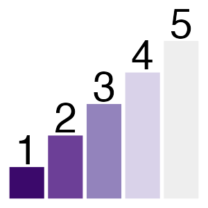

The graphic below shows the color for each student group for each indicator from the California 2022 Dashboard.

[California Dashboard 2022](https://www.caschooldashboard.org/reports/27660500000000/2022)

The graph below displays which student groups qualified King City Union to be eligible for [Differentiated Assistance](https://www.cde.ca.gov/ta/ac/cm/leaproposedcrit.asp). Moreover, for each student group it shows which Priority Areas and associated indicators met qualification criteria.

As a reminder, COEs must offer differentiated assistance to a school district if any student group meets the criteria for two or more LCFF priorities according to California Education Code Section 52071(c). [California’s System of Support](https://www.cde.ca.gov/sp/sw/t1/csss.asp)

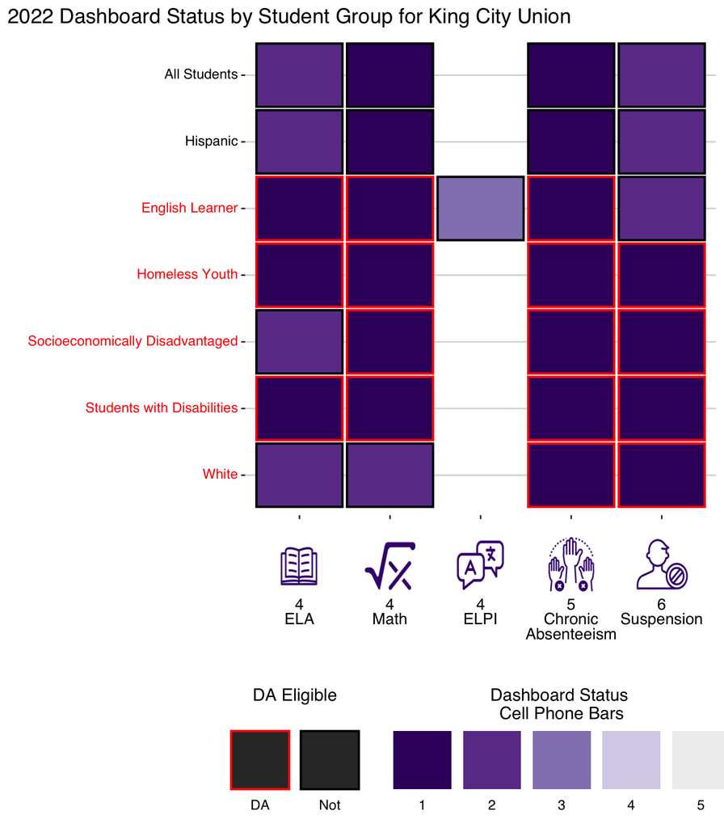

## Status Details for all Indicators

These graphs represent all of the indicators from the Dashboard and show how each of the student groups performed. The vertical lines represent the cutpoints between different status levels.

**Click here to display graphs**

[figure not shown]

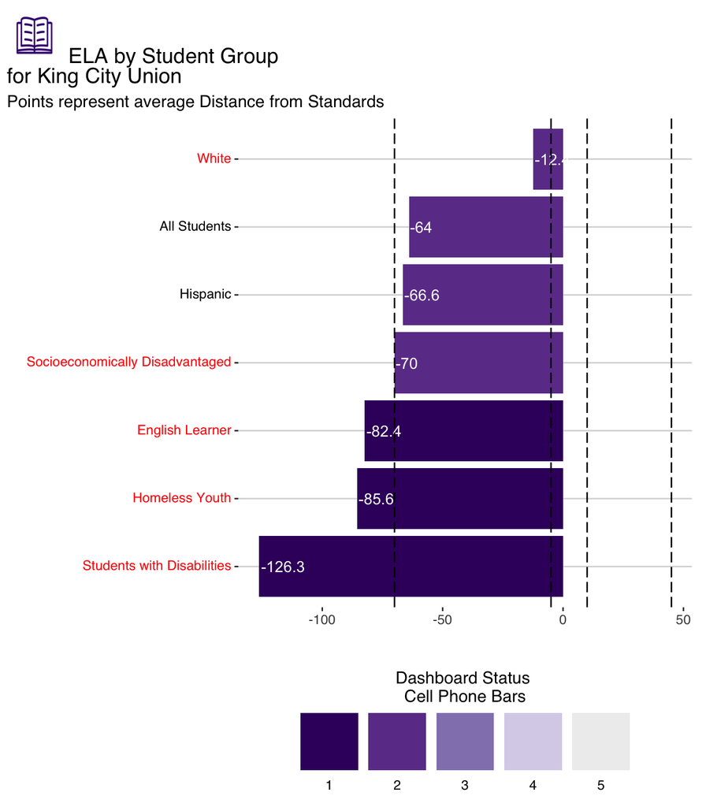

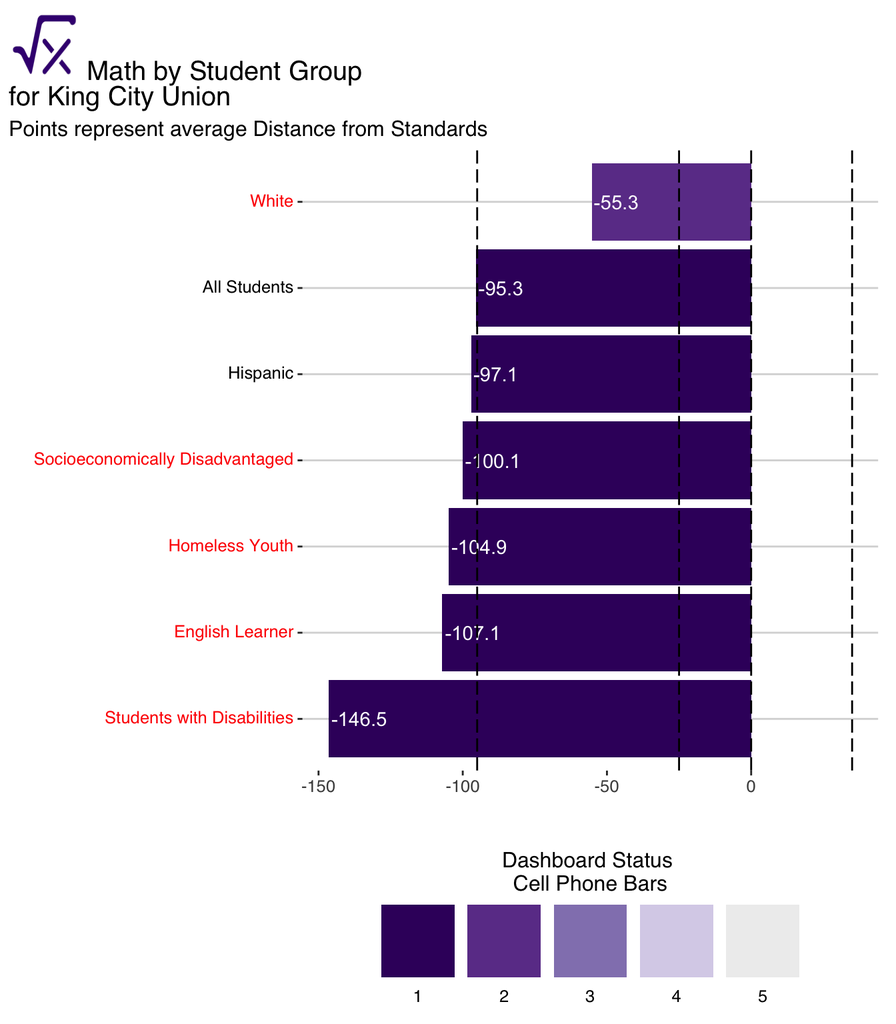

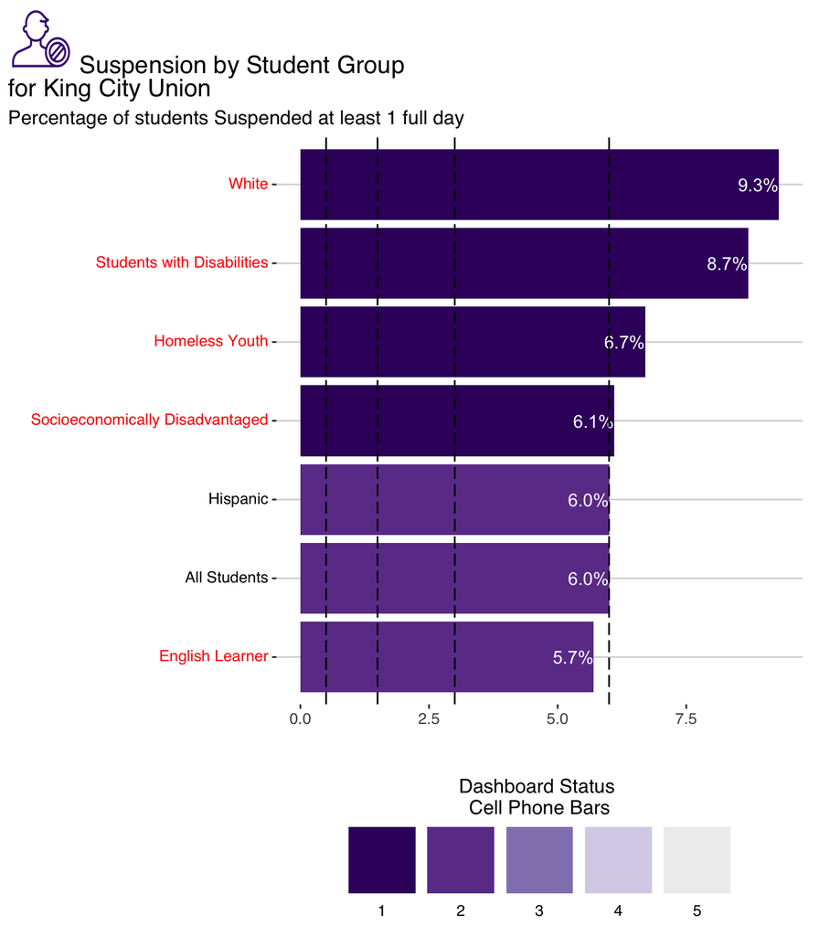

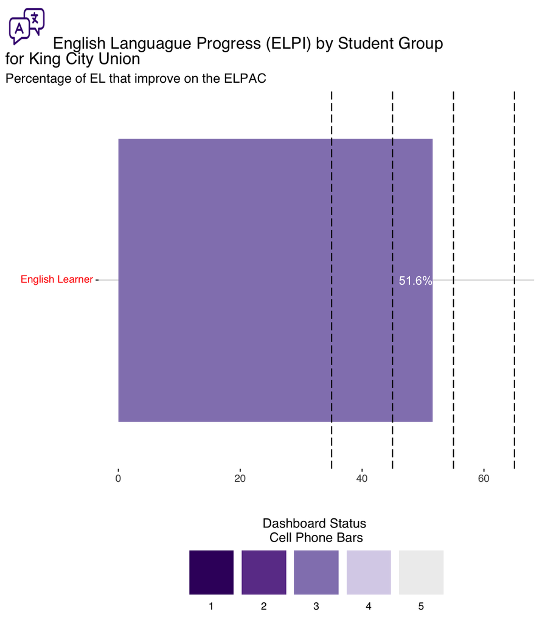

## Historical Graphs for Eligible Groups

These graphs represent all of the indicators from Priority Areas that qualified the district. They included all qualifying subgroups on each graph, whether this was a qualifying indicator or not, as well as the All Students group for comparisons.

**Click here to display graphs**

[figure not shown]

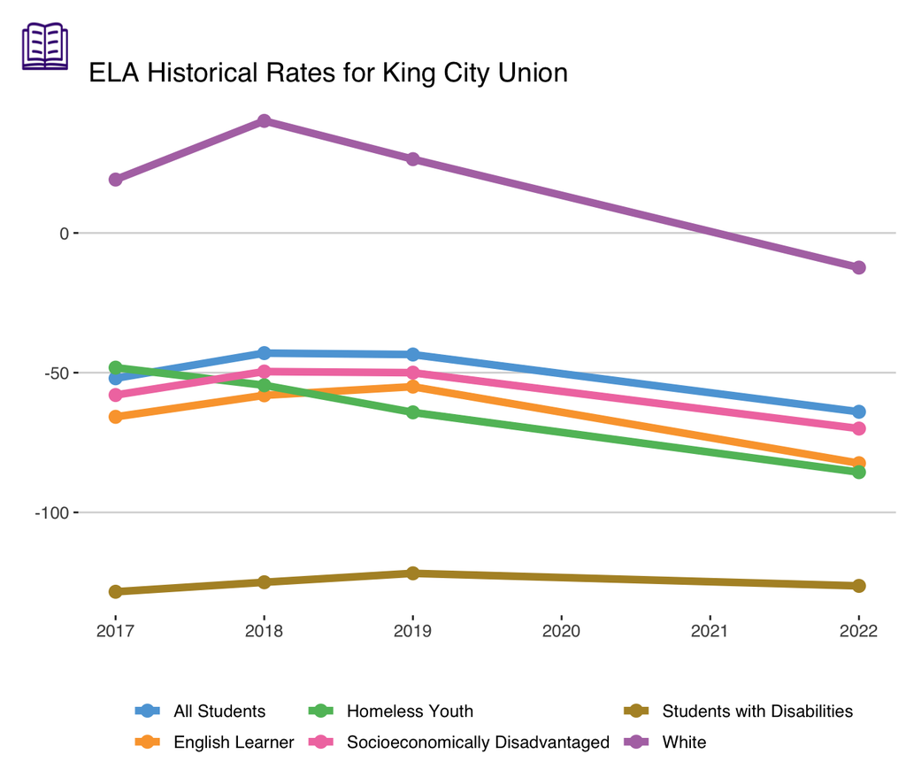

[figure not shown]

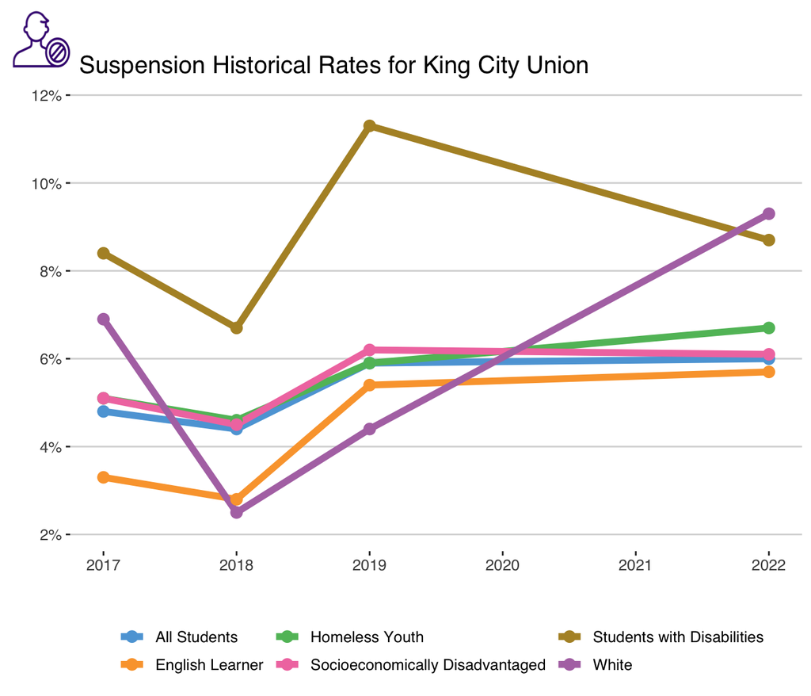

## Status Needed to Exit DA in 2023

This section estimates the limits for relevant indicators to receive an orange or higher color next year on the 2023 Dashboard. The thresholds below are based on the [5x5 grids last approved by the State Board of Education](https://www.cde.ca.gov/ta/ac/cm/fivebyfivecolortables19.asp#AcademicTable) and the number of students in the 2022 calculation. State policies may change and the student counts may shift.

| Student Group | Indicator | Current Status | Target Status for Orange | Change Needed | Number of Students (as applicable) |
| --- | --- | --- | --- | --- | --- |
| English Learner | chronic | 31.5 | 31 | -0.5 | 515 |
| Homeless Youth | chronic | 33 | 32.5 | -0.5 | 133 |
| Socioeconomically Disadvantaged | chronic | 32.3 | 31.8 | -0.5 | 764 |
| Students with Disabilities | chronic | 42.1 | 41.6 | -0.5 | 201 |
| White | chronic | 36.5 | 36 | -0.5 | 30 |
| English Learner | ela | -82.4 | -79.4 | 3 |  |
| English Learner | math | -107.1 | -104.1 | 3 |  |
| Homeless Youth | susp | 6.7 | 6.4 | -0.3 | 26 |
| Socioeconomically Disadvantaged | susp | 6.1 | 6 | -0.0999999999999996 | 147 |
| Students with Disabilities | susp | 8.7 | 8.4 | -0.300000000000001 | 42 |

[output cut: 6 more lines]

The following sentences convey the same information as the table above in a different format for those who prefer written statements.

**Click here to display sentences**

[1] “*English Learner* student group should have 515 or less students **chroncially absent** based on the count in 2022 of 1663 to not be in Red.”  
[2] “*English Learner* student group should have an average of -79.4 from standard or higher based on the **ela** CAASPP exam to not be in Red.”  
[3] “*English Learner* student group should have an average of -104.1 from standard or higher based on the **math** CAASPP exam to not be in Red.”  
[4] “*Homeless Youth* student group should have 133 or less students **chroncially absent** based on the count in 2022 of 412 to not be in Red.”  
[5] “*Homeless Youth* student group should have an average of -82.6 from standard or higher based on the **ela** CAASPP exam to not be in Red.”  
[6] “*Homeless Youth* student group should have an average of -101.9 from standard or higher based on the **math** CAASPP exam to not be in Red.”  
[7] “*Homeless Youth* student group should have 26 or less students **suspended** based on the count in 2022 of 418 to not be in Red.”  
[8] “*Socioeconomically Disadvantaged* student group should have 764 or less students **chroncially absent** based on the count in 2022 of 2404 to not be in Red.” [9] “*Socioeconomically Disadvantaged* student group should have an average of -97.1 from standard or higher based on the **math** CAASPP exam to not be in Red.” [10] “*Socioeconomically Disadvantaged* student group should have 147 or less students **suspended** based on the count in 2022 of 2451 to not be in Red.”  
[11] “*Students with Disabilities* student group should have 201 or less students **chroncially absent** based on the count in 2022 of 484 to not be in Red.”  
[12] “*Students with Disabilities* student group should have an average of -123.3 from standard or higher based on the **ela** CAASPP exam to not be in Red.”  
[13] “*Students with Disabilities* student group should have an average of -143.5 from standard or higher based on the **math** CAASPP exam to not be in Red.”  
[14] “*Students with Disabilities* student group should have 42 or less students **suspended** based on the count in 2022 of 504 to not be in Red.”  
[15] “*White* student group should have 30 or less students **chroncially absent** based on the count in 2022 of 85 to not be in Red.”  
[16] “*White* student group should have 7 or less students **suspended** based on the count in 2022 of 86 to not be in Red.”

This report was generated at 2023-02-02 13:55:16.

It was developed by [David Dobrowski](https://github.com/dobrowski) at the [Monterey County Office of Education](https://www.montereycoe.org/)